# Midterm Project

Jingxiang Li (James)

October 26, 2016

## Introduction

This project is a sales consulting project for General Mills. The main purpose of this project is the analysis the effectivenss of the in-store promotions and advertisements. The data is a representative sample of weekly sales, containing 1,995 observations with information about units, brand, flavor, grain, promotion, advertisment, volume, and sales price.

The most common flavor is **regular**, almost tripled other flavors. The most common grain is **corn**.

There are 81 different products in data set. The best selling product is KELLOGGS FROSTED FLAKES, regular flavor, made by corn, volume is 1.44. Total 811 units of this product was sold.

## Does promotion increase brand’s units per sale?

From the graph below, you can see a significate increase in the number of packages customer most likely to buy when there is a promotion for that brand’s product. To save more money, customers would like to buy more product when it is on sale. Obviously, the promotion is pretty effective across all brand’s product.

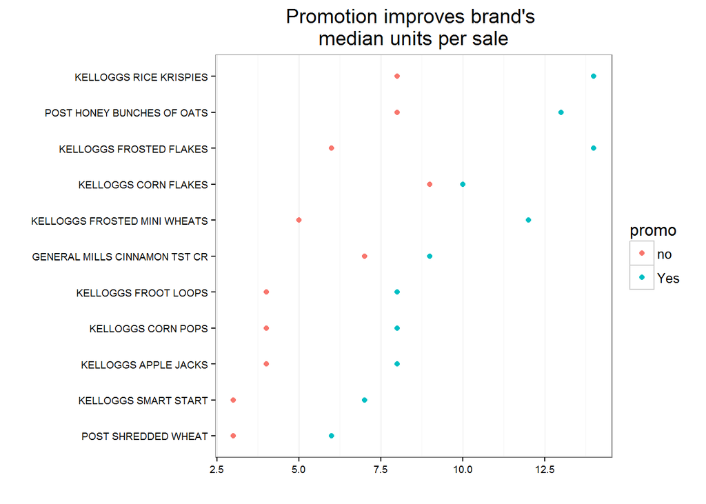

## Comparing advertisement between best and worst brands

Let’s think about why comparing the best and wort brands. Generally, best brands have a good brand recognition already, it is questionable that the extra advertisement spending would boost the sales. For non-popular brands, there is certainly a need to improve their brand image.

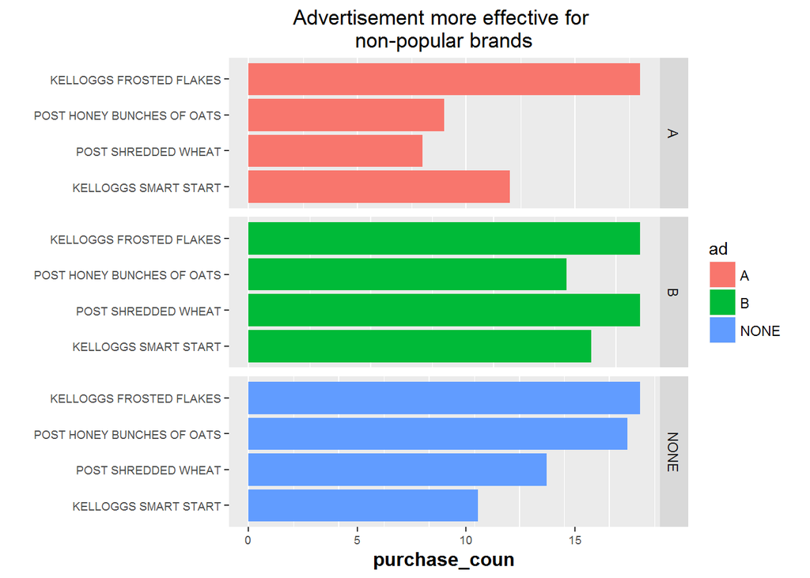

Comparing the sales transaction numbers within each group, it is very interesting to see that medium and small advertisment helps bottom 2 brands beat one of the top 2 brands. In big advertisment, one of bottom brands is better than one of the top brands.

Overall, medium and small ads helps bottom brands catch up with top brands, but advertisment is not very effective for top brand.

## Comparing the two of best selling brands

[figure not shown]

## Concusion

In a nutshell, promotion works pretty well for most brands, and most customers would buy more when the product is on sale. However, the effectiveness of advertisment is really depends on each brand. Overall, medium and small advertiesment is very effective for non-popular brands.

## Technical Appendix

```r
# Midterm Project
# Jingxiang Li (James)
# BUAN 5210
# Oct 26, 2016

# ======================================================= #
# clean environment and load libraries
rm(list = ls(all = TRUE))

library(plyr)
library(dplyr)
library(tidyr)
library(ggplot2)

# load data
oj <- read.csv("6_MTP_Data.csv")
View(oj)  #view data frame

# ======================================================= #
###           I. Univariate non-graphical EDA           ###

# Structure of data
str(oj)

# Review summary statistics
summary(oj)
# about 23.4% sales have in store promotion

### Categorical data

# count and percentage of Advertisment
(count_ad <- as.data.frame(count(oj, ad)) %>%
  mutate(percent_coun = n/sum(n)))
# 6.8% big promo, 6.2% medium/small, 87% no promo

# total package sales by brand
(brand_sales <- oj %>%
  group_by(brand) %>%
  summarise(sales = sum(units)) %>%
  arrange(desc(sales)))
# Sales No.1: POST HONEY BUNCHES OF OATS
# Sales No.2: KELLOGGS FROSTED FLAKES
# Sales No.10: POST SHREDDED WHEAT
# Sales No.11: KELLOGGS SMART START

### interval and continuous data

# summary of data
summary(oj[c(1,5,7,8)])
# units not normal heavily negative skew, mean >> median
# volume and price: mean close to median

# ======================================================= #
###           II. Univariate graphical EDA              ###

# Categorical variables
par(mfrow = c(2,2))
barplot(table(oj$brand), main = "Observations by brand")
barplot(table(oj$flavor),main = "Observations by flavor" )
barplot(table(oj$grain),main = "Observations by grain" )
barplot(table(oj$ad), main = "Observations by advertisment")
# most common flavor is regular, almost tripled other flavors
# most common grain is corn
# followed by whole grain wheat
# most observation brands: KELLOGGS FROSTED FLAKES, POST HONEY BUNCHES OF OATS
# POST HONEY BUNCHES OF OATS has more package sold,
# KELLOGGS FROSTED FLAKES has more transactions

# Continuous variables
par(mfrow = c(2,2))
hist(oj$units, breaks = 20, main = "Dist of units per sale")
hist(oj$volume, breaks = 20, main = "Dist of volumes")
hist(oj$price, breaks = 20, main = "Dist of price")

par(mfrow = c(2,2))
hist(oj$units, breaks = 40, main = "Dist of units per sale")
hist(oj$volume, breaks = 40, main = "Dist of volumes")
hist(oj$price, breaks = 40, main = "Dist of price")
## units per sale: decreasing by units
## dist of price is negative skewed, most common price range is 2.5 - 5

# ======================================================= #
###                 III. Multivariate EDA               ###


# how many distinct products in this data (81)
# and how many packages of each product sold
dist_products <- oj %>%
  group_by(brand, flavor, grain, volume) %>%
  summarise(sales = sum(units)) %>%
  arrange(desc(sales))#81 combinations
# KELLOGGS FROSTED FLAKES-regular-corn-1.44 is the best seller

# ======================================================= #
# does promotion increase brand's units per sale?
# ======================================================= #
oj2 <- oj
oj2$promo <- as.factor(oj2$promo)

promo_oj <- oj2 %>%
  group_by(brand, promo) %>%
  summarise(med_sales = median(units))

ggplot(promo_oj, aes(reorder(brand,med_sales), med_sales, color = promo)) +
  geom_point(stat = "identity") +
  theme_bw() +
  theme(panel.grid.major.y = element_blank()) +
  theme(axis.text=element_text(size=7),
        axis.title=element_text(size=12,face="bold")) +
  scale_color_discrete(labels=c("no", "Yes")) +
  ylab("") +
  xlab("") +
  ggtitle("Promotion improves brand's \nmedian units per sale") +
  coord_flip()

# ==========================================================#
#
# Comparing the advertisements between best and worst
# selling brands
#
# ==========================================================#
# From brand_sales (most units sold)
# Sales No.1: POST HONEY BUNCHES OF OATS
# Sales No.2: KELLOGGS FROSTED FLAKES
# Sales No.10: POST SHREDDED WHEAT
# Sales No.11: KELLOGGS SMART START

adv_oj <- oj2 %>%
  filter(brand %in% c("POST HONEY BUNCHES OF OATS",
                    "KELLOGGS FROSTED FLAKES",
                    "POST SHREDDED WHEAT",
                    "KELLOGGS SMART START")) %>%
  group_by(brand, ad) %>%
  summarise(purchase_coun = n())

ggplot(adv_oj, aes(purchase_coun, reorder(brand,purchase_coun), color = ad)) +
  geom_point(stat = "identity") +
  theme_bw() +
  theme(panel.grid.major.y = element_blank()) +
  facet_grid(ad ~., scales = "free_x", space="fixed")

ggplot(adv_oj, aes(reorder(brand,purchase_coun), purchase_coun, fill = ad)) +
  geom_bar(stat = "identity") +
  coord_flip() +
  theme(panel.grid.major.y = element_blank()) +
  facet_grid(ad ~., scales = "free", space="free") +
  theme(axis.text=element_text(size=7),
        axis.title=element_text(size=12,face="bold")) +
  xlab("") +
  ggtitle("Advertisement more effective for \nnon-popular brands")

# ==========================================================#
#
# Comparing the two of best selling brands
#
# ==========================================================#

best2 <- oj2 %>%
  filter(brand %in% c("POST HONEY BUNCHES OF OATS",
                        "KELLOGGS FROSTED FLAKES")) %>%
  group_by(brand, promo, ad) %>%
  summarise(med_sales = median(units))

ggplot(best2, aes(x = ad, y = med_sales, shape = brand, color = promo)) +
  geom_point(size = 4) +
  theme(legend.position = "bottom") +
  ggtitle("Promotion and advertisement not always help with
          \n median unit per sale") +
  ylab("median units per sale") +
  theme(legend.text=element_text(size = 7))
```